# Predictive Function For Weight Lifting Exercise Dataset

## Creating a Prediction Model

At this point, the data set is clean. However, what we have called the “training set” to this point is needs to be further divided into a new training and new testing set for cross validation purposes since the “testing set” we are using will only be used for grading at the end of the project and really should not be used for cross validation. Below, I have loaded the caret package and divide 60% of the data into a trainingNew data set and 40% into a testingNew.

```r
library(caret)
inTrain<-createDataPartition(y=cleanTraining$classe,p=.6,list=FALSE)
trainingNew<-cleanTraining[inTrain,]
testingNew<-cleanTraining[-inTrain,]

dim(trainingNew)
```

```
## [1] 11776    55
```

```r
dim(testingNew)
```

```
## [1] 7846   55
```

I chose to use the random forest method to generate my predictions. First, I loaded the randomForest library and set my seed. When I generated my model, I set importance to TRUE because I wanted to take a closer look later at which variables were of the most importance to the model with a variable importance plot.

```r
library(randomForest)
set.seed(1234)
modFit<-randomForest(classe~.,data=trainingNew,importance=TRUE)
```

At this point, I could examine how well the model generated by the random forest did by creating a confusion matrix.

```r
predictionsTraining<-predict(modFit,trainingNew)
confusionMatrix(predictionsTraining,trainingNew$classe)
```

```
## Confusion Matrix and Statistics
##
##           Reference
## Prediction    A    B    C    D    E
##          A 3348    0    0    0    0
##          B    0 2279    0    0    0
##          C    0    0 2054    0    0
##          D    0    0    0 1930    0
##          E    0    0    0    0 2165
##
## Overall Statistics
##
##                Accuracy : 1
##                  95% CI : (1, 1)
##     No Information Rate : 0.284
##     P-Value [Acc > NIR] : <2e-16
##
##                   Kappa : 1
##  Mcnemar's Test P-Value : NA
##
## Statistics by Class:
##
##                      Class: A Class: B Class: C Class: D Class: E
## Sensitivity             1.000    1.000    1.000    1.000    1.000
## Specificity             1.000    1.000    1.000    1.000    1.000
## Pos Pred Value          1.000    1.000    1.000    1.000    1.000
## Neg Pred Value          1.000    1.000    1.000    1.000    1.000
## Prevalence              0.284    0.194    0.174    0.164    0.184
## Detection Rate          0.284    0.194    0.174    0.164    0.184
## Detection Prevalence    0.284    0.194    0.174    0.164    0.184
## Balanced Accuracy       1.000    1.000    1.000    1.000    1.000
```

After generating predictions for the training set, the confusion matrix revealed perfect prediction accuracy (Accuracy=1) with respect to the training set.

## Estimating OOB Error with Cross Validation

While this is encouraging, there is always going to be some overfitting that occurs with the training set, and this is likely reflected in this number. Consequently, I now ran predictions and found a confusion matrix for the cross validation test set that I had created.

```r
predictionsTesting<-predict(modFit,testingNew)
confusionMatrix(predictionsTesting,testingNew$classe)
```

```
## Confusion Matrix and Statistics
##
##           Reference
## Prediction    A    B    C    D    E
##          A 2232    7    0    0    0
##          B    0 1508    7    0    0
##          C    0    3 1361    7    0
##          D    0    0    0 1277    3
##          E    0    0    0    2 1439
##
## Overall Statistics
##
##                Accuracy : 0.996
##                  95% CI : (0.995, 0.998)
##     No Information Rate : 0.284
##     P-Value [Acc > NIR] : <2e-16
##
##                   Kappa : 0.995
##  Mcnemar's Test P-Value : NA
##
## Statistics by Class:
##
##                      Class: A Class: B Class: C Class: D Class: E
## Sensitivity             1.000    0.993    0.995    0.993    0.998
## Specificity             0.999    0.999    0.998    1.000    1.000
## Pos Pred Value          0.997    0.995    0.993    0.998    0.999
## Neg Pred Value          1.000    0.998    0.999    0.999    1.000
## Prevalence              0.284    0.193    0.174    0.164    0.184
## Detection Rate          0.284    0.192    0.173    0.163    0.183
## Detection Prevalence    0.285    0.193    0.175    0.163    0.184
## Balanced Accuracy       0.999    0.996    0.997    0.996    0.999
```

Fortunately, the results remained very encouraging. The confusion matrix with the predictions from the “testingNew” still showed accuracy of .996, a very high prediction accuracy in this scenario. This gives an OOB error estimate of .4%.

In order to get a better sense of which variables were of the greatest importance in the model, I used the varImpPlot function.

```r
library(randomForest)
```

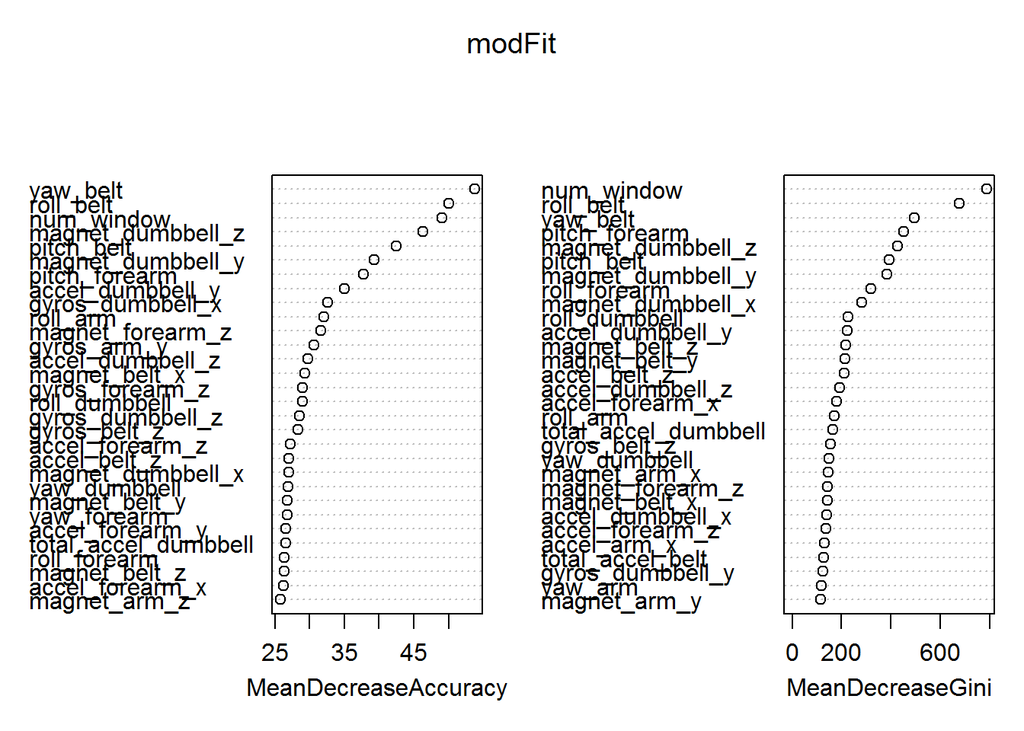

```r
varImpPlot(modFit)
```

Because I used importance=TRUE on my randomForest call earlier, the varImpPlot reveals both the meanDecreaseAccuracy and the meanDecreaseGini. Between the two plots, there many differences over which predictors are the least significant features. However, meanDecreaseAccuracy and meanDecreaseGini plots are mostly in agreement about the most important predictors. We can note that both plots ranked “magnet_dumbbell_z”, “magnet_dumbbell_y”, “num_window”, “pitch_belt”, “pitch_forearm”, “roll_belt”, and “yaw_belt” as the 7 most important features, albeit in different orders.

## Making the Required Predictions

Having cross validated against “testingNew” and obtained a high degree of accuracy, and having examined the most important features with varImpPlot, I began the process of making predictions for the assignment submission. I quickly discovered that making even a simple prediction on a single row resulted in an error message.

A little bit of further research led me to realize that the problem was that when using a model generated by “randomForest”, it is critical to make sure that any factor variables have the same number of levels in the data set that you are making predictions with as they did in the training set. In this case, the variable “new_window” had two levels, “no” and “yes” in the training set, but has only “no” in the testing set that I was using for predictions. This can be addressed easily as follows.

```r
testing$new_window<-factor(testing$new_window,levels=c("no","yes"))
```

From here, it was a simple matter of storing my predictions for grading purposes in a new variable that I called “finalPredictions”.

```r
finalPredictions<-predict(modFit,testing)
```

All predictions stored in this vector were later verified correct.